# Modeling Social Data Project

Aarshay Jain | Bindia Kalra | Keerti Agrawal

May 5, 2017

First we read the data and define the names of new variables created, which are:

Explanatory: * father_involvement * father_presence * num_partners * num_cohab_biof * num_cohab_anyp

Control: * mothers_education * fathers_education * num_cidi_cases * hh_income * kid_punished

```r
library(ggplot2)
library(gridExtra)
library(dplyr)
library(stargazer)
df <- read.csv('FFChallenge/final_data.csv',header = T, stringsAsFactors = F)
features <- c('father_involvement', 'father_presence', 'num_partners', 'num_cohab_biof', 'num_cohab_anyp','mothers_education', 'fathers_education', 'num_cidi_cases', 'hh_income', 'kid_punished')
outcomes <- c('gpa', 'grit')
head(df[features])
```

```
##   father_involvement father_presence num_partners num_cohab_biof
## 1             medium            high            0              3
## 2               high            high            0              4
## 3             medium          medium            1              2
## 4               high            high            0              4
## 5             medium          medium            1              0
## 6             medium          medium            4              0
##   num_cohab_anyp mothers_education fathers_education num_cidi_cases
## 1              3                 3                 1              0
## 2              4                 2                 2              1
## 3              3                 1                 1              1
## 4              4                 3                 3              0
## 5              2                 2                 2              0
## 6              1                 1                 1              0
##   hh_income kid_punished
## 1 10.977241            4
## 2 10.293178            0
## 3 10.049756            2
## 4 10.518804            4
## 5  9.261535            2
## 6  9.572205            2
```

# Recode factors in a logical sequence:

```r
df$father_involvement <- factor(df$father_involvement, levels=c("low","medium","high") )
df$father_presence <- factor(df$father_presence, levels=c("low","medium","high"))
```

# Data Checks:

- missin values

```r
apply(df[c(features,outcomes)],2,function(x) sum(is.na(x)))
```

```
## father_involvement    father_presence       num_partners
##                  0                  0                  0
##     num_cohab_biof     num_cohab_anyp  mothers_education
##                  0                  0                  0
##  fathers_education     num_cidi_cases          hh_income
##                  0                  0                  0
##       kid_punished                gpa               grit
##                  0                  0                  0
```

The summary shows everything looks good.

```r
summary(df[c(features,outcomes)])
```

```
##  father_involvement father_presence  num_partners   num_cohab_biof
##  low   :319         low   :132      Min.   :0.000   Min.   :0.000
##  medium:244         medium:379      1st Qu.:0.000   1st Qu.:0.000
##  high  :386         high  :438      Median :1.000   Median :2.000
##                                     Mean   :1.176   Mean   :1.909
##                                     3rd Qu.:2.000   3rd Qu.:4.000
##                                     Max.   :8.000   Max.   :4.000
##  num_cohab_anyp  mothers_education fathers_education num_cidi_cases
##  Min.   :0.000   Min.   :1.000     Min.   :1.000     Min.   :0.0000
##  1st Qu.:1.000   1st Qu.:1.000     1st Qu.:1.000     1st Qu.:0.0000
##  Median :3.000   Median :2.000     Median :2.000     Median :0.0000
##  Mean   :2.433   Mean   :2.228     Mean   :2.165     Mean   :0.3404
##  3rd Qu.:4.000   3rd Qu.:3.000     3rd Qu.:3.000     3rd Qu.:0.0000
##  Max.   :4.000   Max.   :4.000     Max.   :4.000     Max.   :4.0000
##    hh_income       kid_punished         gpa            grit
##  Min.   : 7.101   Min.   : 0.000   Min.   :1.00   Min.   :1.750
##  1st Qu.: 9.684   1st Qu.: 0.000   1st Qu.:2.50   1st Qu.:3.000
##  Median :10.195   Median : 1.000   Median :3.00   Median :3.500
##  Mean   :10.212   Mean   : 1.703   Mean   :2.88   Mean   :3.443
##  3rd Qu.:10.785   3rd Qu.: 3.000   3rd Qu.:3.50   3rd Qu.:4.000
##  Max.   :11.708   Max.   :12.000   Max.   :4.00   Max.   :4.000
```

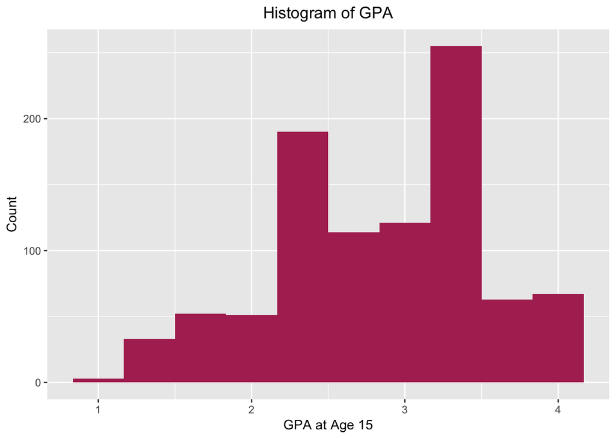

```r
# hist(df$grit)
ggplot(data=df)+
  geom_histogram(aes(x=gpa),bins=10, fill="maroon")+
  xlab("GPA at Age 15") +
  ylab("Count")+
  ggtitle("Histogram of GPA") + theme(plot.title = element_text(hjust = 0.5))
```

Get correlation coefficients:

Correaltion between gpa and grit:

```r
cor(df$gpa,df$grit)
```

```
## [1] 0.2070167
```

Though small magnitudes, we see -ve correlation in num_cidi_cases, num_partners and kid_punished and +ve otherwise as expected.

```r
print('Correlation with GPA:')
```

```
## [1] "Correlation with GPA:"
```

```r
apply(df[features[3:length(features)]],2,function(x) cor(x,y=df$gpa))
```

```
##      num_partners    num_cohab_biof    num_cohab_anyp mothers_education
##       -0.18270138        0.23879478        0.21620022        0.30556781
## fathers_education    num_cidi_cases         hh_income      kid_punished
##        0.31313510       -0.10390097        0.29916649       -0.01886756
```

```r
print('Correlation with Grit:')
```

```
## [1] "Correlation with Grit:"
```

```r
apply(df[features[3:length(features)]],2,function(x) cor(x,y=df$grit))
```

```
##      num_partners    num_cohab_biof    num_cohab_anyp mothers_education
##        0.05639726       -0.08507627       -0.04707836       -0.11191825
## fathers_education    num_cidi_cases         hh_income      kid_punished
##       -0.05759943       -0.05781087       -0.10875741       -0.03932128
```

Make bar chart for father’s involvement and presence:

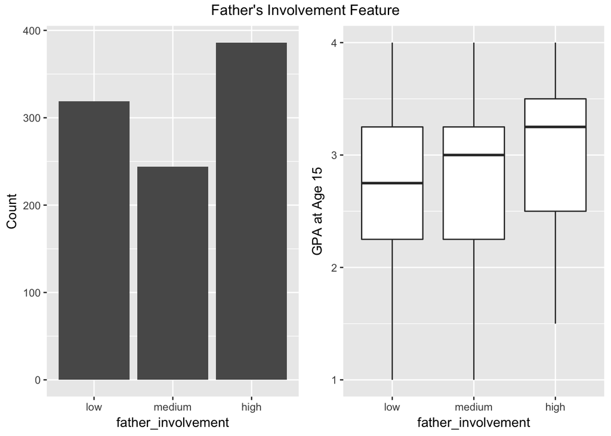

```r
plot1 <- ggplot(data=df) +
  geom_bar(aes(x=father_involvement)) +
  ylab("Count")
 plot2 <- ggplot(data=df) +
  geom_boxplot(aes(x=father_involvement, y=gpa)) +
   ylab("GPA at Age 15")
grid.arrange(plot1, plot2, ncol=2, top="Father's Involvement Feature")
```

Tabulate presence and involvement:

```r
table(df$father_involvement, df$father_presence)
```

```
##
##          low medium high
##   low    125    183   11
##   medium   7    166   71
##   high     0     30  356
```

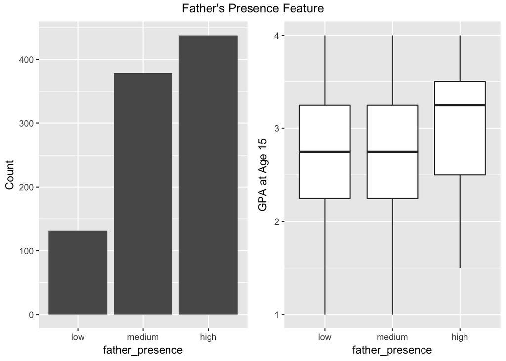

```r
plot1 <- ggplot(data=df) +
  geom_bar(aes(x=father_presence)) +
  ylab("Count")
 plot2 <- ggplot(data=df) +
  geom_boxplot(aes(x=father_presence, y=gpa)) +
   ylab("GPA at Age 15")
grid.arrange(plot1, plot2, ncol=2, top="Father's Presence Feature")
```

Though the boxplots are highly overlapping, we can see that father’s involvement has a slightly positive impact on GPA. Probably there are many confounding factors which we’ll take into consideration in the linear models.

```r
fit <- aov(gpa~father_involvement,data=df)
summary(fit)
```

```
##                     Df Sum Sq Mean Sq F value   Pr(>F)
## father_involvement   2   23.4  11.716   27.14 3.46e-12 ***
## Residuals          946  408.4   0.432
## ---
## Signif. codes:  0 '***' 0.001 '**' 0.01 '*' 0.05 '.' 0.1 ' ' 1
```

```r
fit <- aov(gpa~father_presence,data=df)
summary(fit)
```

```
##                  Df Sum Sq Mean Sq F value   Pr(>F)
## father_presence   2   21.4  10.680   24.62 3.79e-11 ***
## Residuals       946  410.4   0.434
## ---
## Signif. codes:  0 '***' 0.001 '**' 0.01 '*' 0.05 '.' 0.1 ' ' 1
```

```r
# plot(fit)
# TukeyHSD(fit)
```

Make boxplots for father’s involvement on grit:

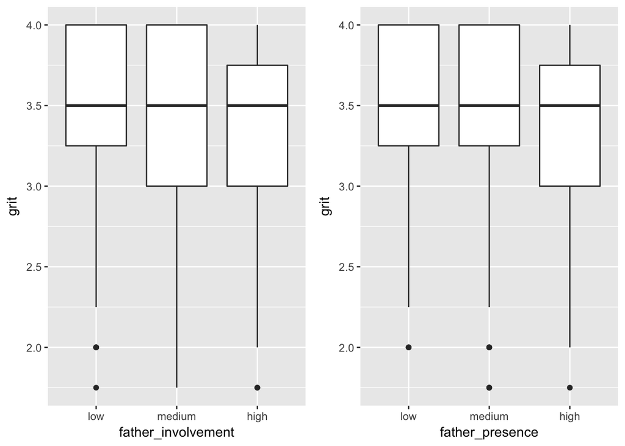

```r
plot1 <- ggplot(data=df) +
  geom_boxplot(aes(x=father_involvement, y=grit))
plot2 <- ggplot(data=df) +
  geom_boxplot(aes(x=father_presence, y=grit))
grid.arrange(plot1, plot2, ncol=2)
```

plot others

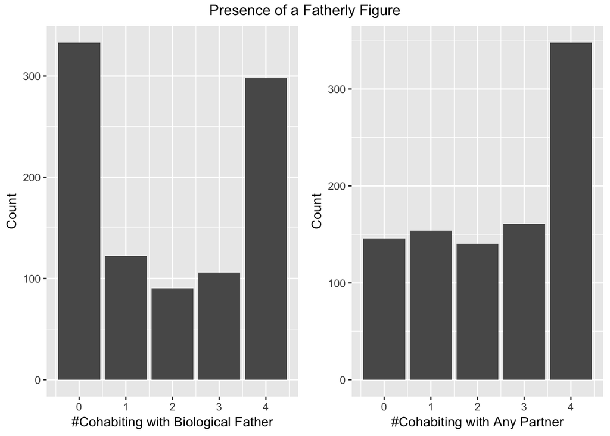

```r
plot1 <- ggplot(data=df) +
  geom_bar(aes(x=num_cohab_biof)) +
  ylab("Count") + xlab("#Cohabiting with Biological Father")
plot2 <- ggplot(data=df) +
  geom_bar(aes(x=num_cohab_anyp)) +
  ylab("Count") + xlab("#Cohabiting with Any Partner")
grid.arrange(plot1, plot2, ncol=2, top="Presence of a Fatherly Figure")
```

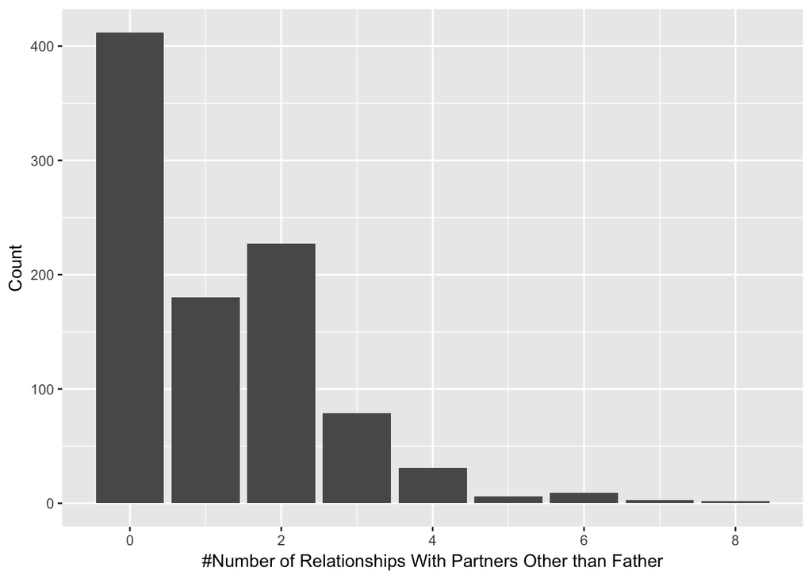

```r
ggplot(data=df) +
  geom_bar(aes(x=num_partners)) +
  ylab("Count") + xlab("#Number of Relationships With Partners Other than Father")
```

# Linear Models:

we’ll start with father’s presence and then keep adding new variables in the model:

```r
lm1 <- lm(gpa~father_presence,data=df)
# summary(lm1)
lm2 <- lm(gpa~num_cohab_biof+father_presence,data=df)
# summary(lm2)
stargazer(lm1,lm2,type="text",report = "vcp*",intercept.bottom = F, omit.stat=c("adj.rsq","ser","f"))
```

```
##
## ==================================================
##                           Dependent variable:
##                       ----------------------------
##                                   gpa
##                             (1)           (2)
## --------------------------------------------------
## Constant                   2.714         2.707
##                        p = 0.000***   p = 0.000***
##
## num_cohab_biof                           0.083
##                                       p = 0.006***
##
## father_presencemedium      0.037         -0.008
##                          p = 0.576     p = 0.903
##
## father_presencehigh        0.328         0.040
##                       p = 0.00000***   p = 0.743
##
## --------------------------------------------------
## Observations                949           949
## R2                         0.049         0.057
## ==================================================
## Note:                  *p<0.1; **p<0.05; ***p<0.01
```

lm2 shows that father_presence is not important in presence of num_cohab_biof which is also a proxy for the same. so we’ll just keep one of them.

```r
lm3 <- lm(gpa~num_cohab_biof + father_presence  + father_involvement, data=df)
lm4 <- lm(gpa~num_cohab_biof + father_involvement, data=df)
stargazer(lm2,lm3,lm4,type="text",report = "vcp*",intercept.bottom = F, omit.stat=c("adj.rsq","ser","f"))
```

```
##
## ===============================================================
##                                   Dependent variable:
##                          --------------------------------------
##                                           gpa
##                              (1)          (2)          (3)
## ---------------------------------------------------------------
## Constant                    2.707        2.704        2.678
##                          p = 0.000*** p = 0.000*** p = 0.000***
##
## num_cohab_biof              0.083        0.063        0.058
##                          p = 0.006*** p = 0.043**  p = 0.006***
##
## father_presencemedium       -0.008       -0.046
##                           p = 0.903    p = 0.531
##
## father_presencehigh         0.040        -0.058
##                           p = 0.743    p = 0.653
##
## father_involvementmedium                 0.086        0.071
##                                        p = 0.182    p = 0.235
##
## father_involvementhigh                   0.195        0.181
##                                       p = 0.024**  p = 0.026**
##
## ---------------------------------------------------------------
## Observations                 949          949          949
## R2                          0.057        0.062        0.062
## ===============================================================
## Note:                               *p<0.1; **p<0.05; ***p<0.01
```

Add more:

```r
df$num_cohab_anyp2 <- df$num_cohab_anyp - df$num_cohab_biof
lm5 <- lm(gpa~num_cohab_biof + father_involvement + num_cohab_anyp2, data=df)
stargazer(lm4,lm5,type="text",report = "vcp*",intercept.bottom = F, omit.stat=c("adj.rsq","ser","f"))
```

```
##
## =====================================================
##                              Dependent variable:
##                          ----------------------------
##                                      gpa
##                               (1)            (2)
## -----------------------------------------------------
## Constant                     2.678          2.641
##                           p = 0.000***  p = 0.000***
##
## num_cohab_biof               0.058          0.063
##                           p = 0.006***  p = 0.003***
##
## father_involvementmedium     0.071          0.081
##                            p = 0.235      p = 0.183
##
## father_involvementhigh       0.181          0.198
##                           p = 0.026**    p = 0.017**
##
## num_cohab_anyp2                             0.033
##                                           p = 0.220
##
## -----------------------------------------------------
## Observations                  949            949
## R2                           0.062          0.063
## =====================================================
## Note:                     *p<0.1; **p<0.05; ***p<0.01
```

```r
lm6 <- lm(gpa~num_cohab_biof + father_involvement + num_cohab_anyp + num_partners, data=df)
stargazer(lm5,lm6,type="text",report = "vcp*",intercept.bottom = F, omit.stat=c("adj.rsq","ser","f"))
```

```
##
## =====================================================
##                              Dependent variable:
##                          ----------------------------
##                                      gpa
##                               (1)            (2)
## -----------------------------------------------------
## Constant                     2.641          2.680
##                           p = 0.000***  p = 0.000***
##
## num_cohab_biof               0.063          0.020
##                           p = 0.003***    p = 0.539
##
## father_involvementmedium     0.081          0.081
##                            p = 0.183      p = 0.180
##
## father_involvementhigh       0.198          0.190
##                           p = 0.017**    p = 0.022**
##
## num_cohab_anyp2              0.033
##                            p = 0.220
##
## num_cohab_anyp                              0.035
##                                           p = 0.195
##
## num_partners                               -0.019
##                                           p = 0.376
##
## -----------------------------------------------------
## Observations                  949            949
## R2                           0.063          0.064
## =====================================================
## Note:                     *p<0.1; **p<0.05; ***p<0.01
```

```r
# lm6 <- lm(gpa~mothers_education+fathers_education+num_cidi_cases+ hh_income+kid_punished,data=df)
# summary(lm6)
lm7 <- lm(gpa~num_cohab_biof + father_involvement + num_cohab_anyp + num_partners +
            mothers_education+fathers_education+num_cidi_cases+ hh_income+kid_punished, data=df)
stargazer(lm6,lm7,type="text",report = "vcp*",intercept.bottom = F, omit.stat=c("adj.rsq","ser","f"))
```

```
##
## =====================================================
##                              Dependent variable:
##                          ----------------------------
##                                      gpa
##                               (1)           (2)
## -----------------------------------------------------
## Constant                     2.680         1.642
##                          p = 0.000***  p = 0.00000***
##
## num_cohab_biof               0.020         -0.007
##                            p = 0.539     p = 0.830
##
## father_involvementmedium     0.081         0.074
##                            p = 0.180     p = 0.202
##
## father_involvementhigh       0.190         0.123
##                           p = 0.022**    p = 0.125
##
## num_cohab_anyp               0.035         0.029
##                            p = 0.195     p = 0.276
##
## num_partners                -0.019         -0.011
##                            p = 0.376     p = 0.586
##
## mothers_education                          0.078
##                                         p = 0.007***
##
## fathers_education                          0.105
##                                        p = 0.0002***
##
## num_cidi_cases                             -0.045
##                                          p = 0.110
##
## hh_income                                  0.074
##                                         p = 0.042**
##
## kid_punished                               -0.012
##                                          p = 0.267
##
## -----------------------------------------------------
## Observations                  949           949
## R2                           0.064         0.146
## =====================================================
## Note:                     *p<0.1; **p<0.05; ***p<0.01
```

```r
lm8 <- lm(gpa~num_cohab_biof + father_involvement + num_cohab_anyp + num_partners +
            mothers_education+fathers_education+ hh_income, data=df)
stargazer(lm7,lm8,type="text",report = "vcp*",intercept.bottom = F, omit.stat=c("adj.rsq","ser","f"))
```

```
##
## ======================================================
##                               Dependent variable:
##                          -----------------------------
##                                       gpa
##                               (1)            (2)
## ------------------------------------------------------
## Constant                     1.642          1.591
##                          p = 0.00000*** p = 0.00001***
##
## num_cohab_biof               -0.007         -0.007
##                            p = 0.830      p = 0.837
##
## father_involvementmedium     0.074          0.076
##                            p = 0.202      p = 0.194
##
## father_involvementhigh       0.123          0.127
##                            p = 0.125      p = 0.113
##
## num_cohab_anyp               0.029          0.026
##                            p = 0.276      p = 0.320
##
## num_partners                 -0.011         -0.014
##                            p = 0.586      p = 0.506
##
## mothers_education            0.078          0.078
##                           p = 0.007***   p = 0.007***
##
## fathers_education            0.105          0.107
##                          p = 0.0002***  p = 0.0002***
##
## num_cidi_cases               -0.045
##                            p = 0.110
##
## hh_income                    0.074          0.076
##                           p = 0.042**    p = 0.038**
##
## kid_punished                 -0.012
##                            p = 0.267
##
## ------------------------------------------------------
## Observations                  949            949
## R2                           0.146          0.143
## ======================================================
## Note:                      *p<0.1; **p<0.05; ***p<0.01
```